# Ford GoBike System Data Exploration

## Preliminary Wrangling

> This data set includes information about individual rides made in a bike-sharing system covering the greater San Francisco Bay area in February 2019.

```python
# import all packages and set plots to be embedded inline
import numpy as np
import pandas as pd
import matplotlib.pyplot as plt
import seaborn as sb

%matplotlib inline
```

```python
# suppress scientific notation for floats (expo)
#pd.set_option('display.float_format', lambda x: '%.6f' % x)

# expanding full text
pd.set_option('display.max_colwidth', -1)
```

```python
org_df = pd.read_csv("201902-fordgobike-tripdata.csv")
org_df.head()
```

|  | duration_sec | start_time | end_time | start_station_id | start_station_name | start_station_latitude | start_station_longitude | end_station_id | end_station_name | end_station_latitude | end_station_longitude | bike_id | user_type | member_birth_year | member_gender | bike_share_for_all_trip |
| --- | --- | --- | --- | --- | --- | --- | --- | --- | --- | --- | --- | --- | --- | --- | --- | --- |
| 0 | 52185 | 2019-02-28 17:32:10.1450 | 2019-03-01 08:01:55.9750 | 21.0 | Montgomery St BART Station (Market St at 2nd St) | 37.789625 | -122.400811 | 13.0 | Commercial St at Montgomery St | 37.794231 | -122.402923 | 4902 | Customer | 1984.0 | Male | No |
| 1 | 42521 | 2019-02-28 18:53:21.7890 | 2019-03-01 06:42:03.0560 | 23.0 | The Embarcadero at Steuart St | 37.791464 | -122.391034 | 81.0 | Berry St at 4th St | 37.775880 | -122.393170 | 2535 | Customer | NaN | NaN | No |
| 2 | 61854 | 2019-02-28 12:13:13.2180 | 2019-03-01 05:24:08.1460 | 86.0 | Market St at Dolores St | 37.769305 | -122.426826 | 3.0 | Powell St BART Station (Market St at 4th St) | 37.786375 | -122.404904 | 5905 | Customer | 1972.0 | Male | No |
| 3 | 36490 | 2019-02-28 17:54:26.0100 | 2019-03-01 04:02:36.8420 | 375.0 | Grove St at Masonic Ave | 37.774836 | -122.446546 | 70.0 | Central Ave at Fell St | 37.773311 | -122.444293 | 6638 | Subscriber | 1989.0 | Other | No |
| 4 | 1585 | 2019-02-28 23:54:18.5490 | 2019-03-01 00:20:44.0740 | 7.0 | Frank H Ogawa Plaza | 37.804562 | -122.271738 | 222.0 | 10th Ave at E 15th St | 37.792714 | -122.248780 | 4898 | Subscriber | 1974.0 | Male | Yes |

```python
print(org_df.shape)
print(org_df.dtypes)
```

```
(183412, 16)
duration_sec               int64
start_time                 object
end_time                   object
start_station_id           float64
start_station_name         object
start_station_latitude     float64
start_station_longitude    float64
end_station_id             float64
end_station_name           object
end_station_latitude       float64
end_station_longitude      float64
bike_id                    int64
user_type                  object
member_birth_year          float64
member_gender              object
bike_share_for_all_trip    object
dtype: object
```

```python
org_df.isna().any()
```

```
duration_sec               False
start_time                 False
end_time                   False
start_station_id           True
start_station_name         True
start_station_latitude     False
start_station_longitude    False
end_station_id             True
end_station_name           True
end_station_latitude       False
end_station_longitude      False
bike_id                    False
user_type                  False
member_birth_year          True
member_gender              True
bike_share_for_all_trip    False
dtype: bool
```

```python
org_df.isna().sum()
```

```
duration_sec               0
start_time                 0
end_time                   0
start_station_id           197
start_station_name         197
start_station_latitude     0
start_station_longitude    0
end_station_id             197
end_station_name           197
end_station_latitude       0
end_station_longitude      0
bike_id                    0
user_type                  0
member_birth_year          8265
member_gender              8265
bike_share_for_all_trip    0
dtype: int64
```

```python
org_df[org_df.start_station_id.isna()].sample(5)
```

|  | duration_sec | start_time | end_time | start_station_id | start_station_name | start_station_latitude | start_station_longitude | end_station_id | end_station_name | end_station_latitude | end_station_longitude | bike_id | user_type | member_birth_year | member_gender | bike_share_for_all_trip |
| --- | --- | --- | --- | --- | --- | --- | --- | --- | --- | --- | --- | --- | --- | --- | --- | --- |
| 80120 | 426 | 2019-02-18 16:16:40.1930 | 2019-02-18 16:23:46.5840 | NaN | NaN | 37.42 | -121.95 | NaN | NaN | 37.41 | -121.96 | 4239 | Subscriber | 1999.0 | Male | No |
| 79942 | 638 | 2019-02-18 16:33:30.0910 | 2019-02-18 16:44:08.3850 | NaN | NaN | 37.41 | -121.94 | NaN | NaN | 37.42 | -121.96 | 4095 | Subscriber | 1987.0 | Male | No |
| 78918 | 1872 | 2019-02-18 18:00:31.5670 | 2019-02-18 18:31:43.6900 | NaN | NaN | 37.40 | -121.93 | NaN | NaN | 37.40 | -121.93 | 4207 | Customer | 1988.0 | Male | No |
| 131475 | 527 | 2019-02-09 12:24:39.8020 | 2019-02-09 12:33:26.9450 | NaN | NaN | 37.42 | -121.96 | NaN | NaN | 37.41 | -121.96 | 4239 | Subscriber | 1977.0 | Male | No |
| 28216 | 168 | 2019-02-25 08:57:37.0280 | 2019-02-25 09:00:25.7340 | NaN | NaN | 37.41 | -121.96 | NaN | NaN | 37.41 | -121.95 | 4283 | Subscriber | 1988.0 | Male | No |

```python
org_df[(org_df.start_station_latitude == 37.40) & (org_df.start_station_longitude == -121.94)].start_station_name.unique()
```

```
array([nan], dtype=object)
```

```python
org_df[org_df.member_gender.isna()].sample(15)
```

|  | duration_sec | start_time | end_time | start_station_id | start_station_name | start_station_latitude | start_station_longitude | end_station_id | end_station_name | end_station_latitude | end_station_longitude | bike_id | user_type | member_birth_year | member_gender | bike_share_for_all_trip |
| --- | --- | --- | --- | --- | --- | --- | --- | --- | --- | --- | --- | --- | --- | --- | --- | --- |
| 141578 | 460 | 2019-02-07 17:52:36.7650 | 2019-02-07 18:00:17.5610 | 318.0 | San Carlos St at Market St | 37.330698 | -121.888979 | 312.0 | San Jose Diridon Station | 37.329732 | -121.901782 | 4217 | Subscriber | NaN | NaN | No |
| 178911 | 752 | 2019-02-01 15:58:06.0680 | 2019-02-01 16:10:38.2300 | 28.0 | The Embarcadero at Bryant St | 37.787168 | -122.388098 | 6.0 | The Embarcadero at Sansome St | 37.804770 | -122.403234 | 2427 | Customer | NaN | NaN | No |
| 138857 | 57059 | 2019-02-07 12:17:12.2950 | 2019-02-08 04:08:11.3190 | 7.0 | Frank H Ogawa Plaza | 37.804562 | -122.271738 | 47.0 | 4th St at Harrison St | 37.780955 | -122.399749 | 1357 | Customer | NaN | NaN | No |
| 71219 | 873 | 2019-02-19 17:33:34.7020 | 2019-02-19 17:48:08.0480 | 349.0 | Howard St at Mary St | 37.781010 | -122.405666 | 127.0 | Valencia St at 21st St | 37.756708 | -122.421025 | 4372 | Subscriber | NaN | NaN | No |
| 119645 | 235 | 2019-02-11 17:45:38.1720 | 2019-02-11 17:49:33.2820 | 80.0 | Townsend St at 5th St | 37.775235 | -122.397437 | 345.0 | Hubbell St at 16th St | 37.766483 | -122.398279 | 5533 | Subscriber | NaN | NaN | No |
| 131391 | 1559 | 2019-02-09 12:42:33.9360 | 2019-02-09 13:08:33.8860 | 58.0 | Market St at 10th St | 37.776619 | -122.417385 | 29.0 | O'Farrell St at Divisadero St | 37.782405 | -122.439446 | 4814 | Subscriber | NaN | NaN | No |
| 28381 | 350 | 2019-02-25 08:46:14.8120 | 2019-02-25 08:52:05.7580 | 125.0 | 20th St at Bryant St | 37.759200 | -122.409851 | 110.0 | 17th & Folsom Street Park (17th St at Folsom St) | 37.763708 | -122.415204 | 3661 | Subscriber | NaN | NaN | No |
| 180707 | 229 | 2019-02-01 10:19:30.2740 | 2019-02-01 10:23:19.5310 | 211.0 | Broadway at 40th St | 37.827757 | -122.256716 | 176.0 | MacArthur BART Station | 37.828410 | -122.266315 | 5095 | Subscriber | NaN | NaN | No |
| 26249 | 1379 | 2019-02-25 12:48:01.7410 | 2019-02-25 13:11:01.3270 | 182.0 | 19th Street BART Station | 37.809013 | -122.268247 | 162.0 | Franklin St at 9th St | 37.800516 | -122.272080 | 2745 | Customer | NaN | NaN | No |
| 41780 | 3691 | 2019-02-22 17:16:54.2400 | 2019-02-22 18:18:26.1610 | 239.0 | Bancroft Way at Telegraph Ave | 37.868813 | -122.258764 | 243.0 | Bancroft Way at College Ave | 37.869360 | -122.254337 | 2482 | Customer | NaN | NaN | No |
| 68175 | 275 | 2019-02-20 06:13:24.2210 | 2019-02-20 06:18:00.0920 | 108.0 | 16th St Mission BART | 37.764710 | -122.419957 | 100.0 | Bryant St at 15th St | 37.767100 | -122.410662 | 6575 | Subscriber | NaN | NaN | No |
| 96028 | 253 | 2019-02-15 11:48:32.2990 | 2019-02-15 11:52:45.7960 | 86.0 | Market St at Dolores St | 37.769305 | -122.426826 | 109.0 | 17th St at Valencia St | 37.763316 | -122.421904 | 5366 | Subscriber | NaN | NaN | No |
| 88409 | 649 | 2019-02-16 18:35:22.5920 | 2019-02-16 18:46:12.1670 | 287.0 | Almaden Blvd at Balbach St | 37.326730 | -121.889273 | 307.0 | SAP Center | 37.332692 | -121.900084 | 2929 | Customer | NaN | NaN | No |
| 88446 | 1006 | 2019-02-16 18:17:17.1150 | 2019-02-16 18:34:03.4180 | 123.0 | Folsom St at 19th St | 37.760594 | -122.414817 | 127.0 | Valencia St at 21st St | 37.756708 | -122.421025 | 1864 | Customer | NaN | NaN | No |
| 141727 | 718 | 2019-02-07 17:41:07.9540 | 2019-02-07 17:53:06.2050 | 62.0 | Victoria Manalo Draves Park | 37.777791 | -122.406432 | 15.0 | San Francisco Ferry Building (Harry Bridges Plaza) | 37.795392 | -122.394203 | 3716 | Subscriber | NaN | NaN | No |

```python
org_df[org_df.member_gender.isna()].member_birth_year.unique()
```

```
array([nan])
```

Check for duplicated rows

```python
org_df.duplicated().any()
```

```
False
```

```python
org_df.end_station_id.sample(20)
```

```
152205    258.0
86224     200.0
117351    109.0
165025    256.0
52923     67.0
99610     8.0
116901    80.0
156879    19.0
13316     58.0
41947     377.0
79352     351.0
151948    268.0
53549     41.0
21984     20.0
166029    11.0
7373      124.0
154911    59.0
2690      270.0
119463    246.0
165946    114.0
Name: end_station_id, dtype: float64
```

### Clean

Create df for cleaning of the original dataframe

```python
df = org_df.copy()
df.head()
```

|  | duration_sec | start_time | end_time | start_station_id | start_station_name | start_station_latitude | start_station_longitude | end_station_id | end_station_name | end_station_latitude | end_station_longitude | bike_id | user_type | member_birth_year | member_gender | bike_share_for_all_trip |
| --- | --- | --- | --- | --- | --- | --- | --- | --- | --- | --- | --- | --- | --- | --- | --- | --- |
| 0 | 52185 | 2019-02-28 17:32:10.1450 | 2019-03-01 08:01:55.9750 | 21.0 | Montgomery St BART Station (Market St at 2nd St) | 37.789625 | -122.400811 | 13.0 | Commercial St at Montgomery St | 37.794231 | -122.402923 | 4902 | Customer | 1984.0 | Male | No |
| 1 | 42521 | 2019-02-28 18:53:21.7890 | 2019-03-01 06:42:03.0560 | 23.0 | The Embarcadero at Steuart St | 37.791464 | -122.391034 | 81.0 | Berry St at 4th St | 37.775880 | -122.393170 | 2535 | Customer | NaN | NaN | No |
| 2 | 61854 | 2019-02-28 12:13:13.2180 | 2019-03-01 05:24:08.1460 | 86.0 | Market St at Dolores St | 37.769305 | -122.426826 | 3.0 | Powell St BART Station (Market St at 4th St) | 37.786375 | -122.404904 | 5905 | Customer | 1972.0 | Male | No |
| 3 | 36490 | 2019-02-28 17:54:26.0100 | 2019-03-01 04:02:36.8420 | 375.0 | Grove St at Masonic Ave | 37.774836 | -122.446546 | 70.0 | Central Ave at Fell St | 37.773311 | -122.444293 | 6638 | Subscriber | 1989.0 | Other | No |
| 4 | 1585 | 2019-02-28 23:54:18.5490 | 2019-03-01 00:20:44.0740 | 7.0 | Frank H Ogawa Plaza | 37.804562 | -122.271738 | 222.0 | 10th Ave at E 15th St | 37.792714 | -122.248780 | 4898 | Subscriber | 1974.0 | Male | Yes |

```python
df.dropna(inplace = True)

# reset index after dropping null values
df.reset_index(inplace = True, drop = True)
# check for null values of drop
df.isna().any()
```

```
duration_sec               False
start_time                 False
end_time                   False
start_station_id           False
start_station_name         False
start_station_latitude     False
start_station_longitude    False
end_station_id             False
end_station_name           False
end_station_latitude       False
end_station_longitude      False
bike_id                    False
user_type                  False
member_birth_year          False
member_gender              False
bike_share_for_all_trip    False
dtype: bool
```

```python
df.shape
```

```
(174952, 16)
```

#### Check for duplicates

```python
df.duplicated().sum()
```

```
0
```

#### Check if there is non-decimals in ids values -float types (not to cause problems when converting to ints)

```python
print(df.start_station_id.apply(float.is_integer).all())

print(df.end_station_id.apply(float.is_integer).all())
```

```
True
True
```

#### Converting to proper types

```python
# convert start and end time to datetime objects
df['start_time'] = pd.to_datetime(df['start_time'])

df['end_time'] = pd.to_datetime(df['end_time'])
```

```python
# convert station start and end ids to integers
df['start_station_id'] = df['start_station_id'].astype(int)

df['end_station_id'] = df['end_station_id'].astype(int)
```

```python
# convert member birth year to int
df['member_birth_year'] = df['member_birth_year'].astype(int)
```

```python
df['member_age'] = 2019 - df['member_birth_year']
```

```python
# check for successful conversion
df.dtypes
```

```
duration_sec               int64
start_time                 datetime64[ns]
end_time                   datetime64[ns]
start_station_id           int64
start_station_name         object
start_station_latitude     float64
start_station_longitude    float64
end_station_id             int64
end_station_name           object
end_station_latitude       float64
end_station_longitude      float64
bike_id                    int64
user_type                  object
member_birth_year          int64
member_gender              object
bike_share_for_all_trip    object
member_age                 int64
dtype: object
```

#### Drop columns of no use in analysis

```python
df.drop(['start_station_latitude','start_station_longitude', 'end_station_latitude', 'end_station_longitude', 'bike_id'], axis = 1, inplace = True)
```

### What is/are the main feature(s) of interest in your dataset?

> Main interest is the duration of trip, trips frequency by time and User types (specifically Subscriber) in terms of factors affecting and patterns.

### What features in the dataset do you think will help support your investigation into your feature(s) of interest?

> I expect member's age and gender would be main assets in predicting User type. Time of the trip is expected to be the most important factor in predicting duration of trip.

## Univariate Exploration

```python
df.shape
```

```
(174952, 12)
```

```python
df.columns
```

```
Index(['duration_sec', 'start_time', 'end_time', 'start_station_id',
       'start_station_name', 'end_station_id', 'end_station_name', 'user_type',
       'member_birth_year', 'member_gender', 'bike_share_for_all_trip',
       'member_age'],
      dtype='object')
```

```python
# for numeric vars only
df.describe()
```

|  | duration_sec | start_station_id | end_station_id | member_birth_year | member_age |
| --- | --- | --- | --- | --- | --- |
| count | 174952.000000 | 174952.000000 | 174952.000000 | 174952.000000 | 174952.000000 |
| mean | 704.002744 | 139.002126 | 136.604486 | 1984.803135 | 34.196865 |
| std | 1642.204905 | 111.648819 | 111.335635 | 10.118731 | 10.118731 |
| min | 61.000000 | 3.000000 | 3.000000 | 1878.000000 | 18.000000 |
| 25% | 323.000000 | 47.000000 | 44.000000 | 1980.000000 | 27.000000 |
| 50% | 510.000000 | 104.000000 | 101.000000 | 1987.000000 | 32.000000 |
| 75% | 789.000000 | 239.000000 | 238.000000 | 1992.000000 | 39.000000 |
| max | 84548.000000 | 398.000000 | 398.000000 | 2001.000000 | 141.000000 |

Starting by looking at Member's features

```python
gender_count = df.member_gender.value_counts()
gender_count
```

```
Male      130500
Female    40805
Other     3647
Name: member_gender, dtype: int64
```

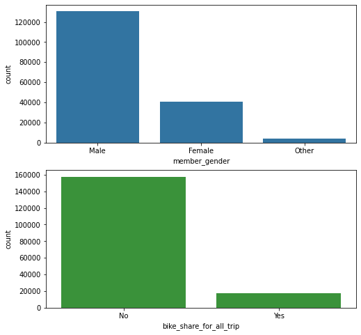

```python
# let's plot all three together to get an idea of each ordinal variable's distribution.

fig, ax = plt.subplots(nrows=2, figsize = [8,8])

default_color = sb.color_palette()[0]

sb.countplot(data = df, x = 'member_gender', order= gender_count.index, color = sb.color_palette()[0], ax = ax[0])

sb.countplot(data = df, x = 'bike_share_for_all_trip', color = sb.color_palette()[2], ax = ax[1])

plt.show()
```

Most members are Male then comes Female then a small proportion Other

Vast majority of Members are not in bike share for all.

Looking at the main feature user_type

```python
user_count = df.user_type.value_counts()
user_count
```

```
Subscriber    158386
Customer      16566
Name: user_type, dtype: int64
```

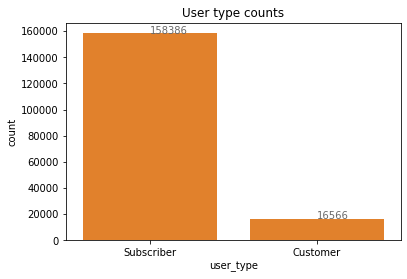

```python
# plot Count of user_count column

sb.countplot(data= df, x= 'user_type', order= user_count.index, color= sb.color_palette()[1]);

for i in range(user_count.shape[0]):
    count = user_count[i]
    plt.text(i, count, count, color = 'dimgray')

plt.title("User type counts");
```

Vast majority of Members are Subscribers with a number of Customers

Looking at distribution of Member's Age

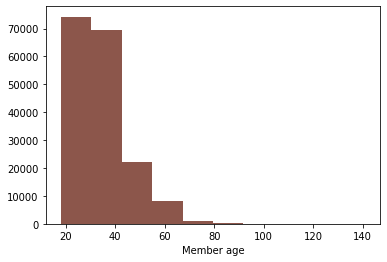

```python
# Distribution of member_birth_year
plt.hist(data= df, x= "member_age", color= sb.color_palette()[-5])
plt.xlabel("Member age");
```

Distribution is right-skewed as Members of age more than approx 65 are high outliers.

taking a limit cancelling very high outliers for further analysis of age

```python
# check for number of rows age > 80 before cut
df[df['member_age'] > 80].shape[0]
```

```
192
```

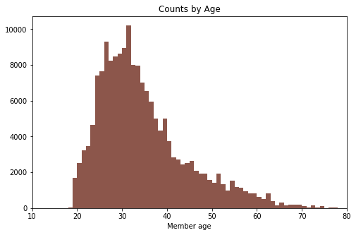

```python
# Distribution of member_birth_year
plt.figure(figsize=[8,5])

bins = np.arange(df['member_age'].min(), df['member_age'].max() + 1, 1)
plt.hist(data= df, x= "member_age", bins = bins, color= sb.color_palette()[-5])

plt.xlabel("Member age")
plt.xlim(10, 80)
#plt.xticks(np.arange(10,81,5))
plt.title("Counts by Age");
```

Distribution of birth year seems bi-modal with two peaks for age 26 and another 31. Most members are born in age ranges of between 24 to 37 with highest peak at age 31. There is a sudden increased shift for members count after age 23, and a sudden continous drop in members count after age 40.

Clean based on age as oldest person alive is 118 years old, therefore higher outliers are unacceptable.

```python
df = df[df['member_age'] < 118]
```

#### Time

Looking at distribution of days of the month to remark patterns in frequency of trips over time

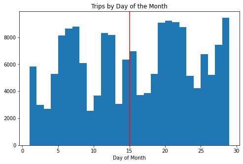

```python
# plot distribution of trips each day
# added +2 so day 28 be a separete bin from day 27 /instead of +1
# bin for each day of the month
plt.figure(figsize = [8,5])

# could do barplots countplot(x = )
bins = np.arange(df['start_time'].dt.day.min(), df['start_time'].dt.day.max() + 2, 1)
# grid is added by default
df['start_time'].dt.day.hist(bins = bins , grid = False)

plt.axvline(15, color = 'red')
plt.xlabel("Day of Month")
plt.title("Trips by Day of the Month");
```

Trips count seem to be varying along days of the month between increase and decrease. Trips counts is particulary highest between day 5 to 7, 19 to 22, and on day 28 as well. Sharp drops happened after the two continous days peaks with the sharpest drop occuring on day 9 which has the least number of trips.

Further search for day patterns using days of the week by weekday order

```python
# Create a column for name of day of the week

# day_name() method gets the name of the day in the week
df['weekday'] = df['start_time'].dt.day_name()

# order by weekday order instead of passing order = to plot each time
weekend_order = [ 'Monday', 'Tuesday', 'Wednesday', 'Thursday', 'Friday', 'Saturday', 'Sunday']
weekclasses = pd.api.types.CategoricalDtype(ordered = True, categories = weekend_order)
df['weekday'] = df['weekday'].astype(weekclasses)

df.head()
```

|  | duration_sec | start_time | end_time | start_station_id | start_station_name | end_station_id | end_station_name | user_type | member_birth_year | member_gender | bike_share_for_all_trip | member_age | weekday |
| --- | --- | --- | --- | --- | --- | --- | --- | --- | --- | --- | --- | --- | --- |
| 0 | 52185 | 2019-02-28 17:32:10.145 | 2019-03-01 08:01:55.975 | 21 | Montgomery St BART Station (Market St at 2nd St) | 13 | Commercial St at Montgomery St | Customer | 1984 | Male | No | 35 | Thursday |
| 1 | 61854 | 2019-02-28 12:13:13.218 | 2019-03-01 05:24:08.146 | 86 | Market St at Dolores St | 3 | Powell St BART Station (Market St at 4th St) | Customer | 1972 | Male | No | 47 | Thursday |
| 2 | 36490 | 2019-02-28 17:54:26.010 | 2019-03-01 04:02:36.842 | 375 | Grove St at Masonic Ave | 70 | Central Ave at Fell St | Subscriber | 1989 | Other | No | 30 | Thursday |
| 3 | 1585 | 2019-02-28 23:54:18.549 | 2019-03-01 00:20:44.074 | 7 | Frank H Ogawa Plaza | 222 | 10th Ave at E 15th St | Subscriber | 1974 | Male | Yes | 45 | Thursday |
| 4 | 1793 | 2019-02-28 23:49:58.632 | 2019-03-01 00:19:51.760 | 93 | 4th St at Mission Bay Blvd S | 323 | Broadway at Kearny | Subscriber | 1959 | Male | No | 60 | Thursday |

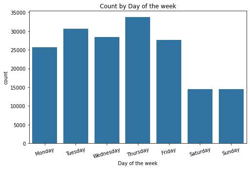

```python
# plot count by day of the week
plt.figure(figsize = [8,5])

# could use df['start_time'].dt.day_name().value_counts().reindex(weekend_order) and a barplot/ or convert to ordinal categorical astype()

sb.countplot(x = df['weekday'], color = sb.color_palette()[0])

plt.xticks(rotation = 15)
plt.xlabel("Day of the week")
plt.title("Count by Day of the week");
```

Trips tend to be of high frequency at start of weekdays with a peak on Tuesday and highest peak on Thursday. Trips frequency is very low on weekends Saturday and Sunday.

Moving to **Hour of the day**

```python
# take start hour as approximation of trip hour on average
df['hour'] = df['start_time'].dt.hour
df.head()
```

|  | duration_sec | start_time | end_time | start_station_id | start_station_name | end_station_id | end_station_name | user_type | member_birth_year | member_gender | bike_share_for_all_trip | member_age | weekday | hour |
| --- | --- | --- | --- | --- | --- | --- | --- | --- | --- | --- | --- | --- | --- | --- |
| 0 | 52185 | 2019-02-28 17:32:10.145 | 2019-03-01 08:01:55.975 | 21 | Montgomery St BART Station (Market St at 2nd St) | 13 | Commercial St at Montgomery St | Customer | 1984 | Male | No | 35 | Thursday | 17 |
| 1 | 61854 | 2019-02-28 12:13:13.218 | 2019-03-01 05:24:08.146 | 86 | Market St at Dolores St | 3 | Powell St BART Station (Market St at 4th St) | Customer | 1972 | Male | No | 47 | Thursday | 12 |
| 2 | 36490 | 2019-02-28 17:54:26.010 | 2019-03-01 04:02:36.842 | 375 | Grove St at Masonic Ave | 70 | Central Ave at Fell St | Subscriber | 1989 | Other | No | 30 | Thursday | 17 |
| 3 | 1585 | 2019-02-28 23:54:18.549 | 2019-03-01 00:20:44.074 | 7 | Frank H Ogawa Plaza | 222 | 10th Ave at E 15th St | Subscriber | 1974 | Male | Yes | 45 | Thursday | 23 |
| 4 | 1793 | 2019-02-28 23:49:58.632 | 2019-03-01 00:19:51.760 | 93 | 4th St at Mission Bay Blvd S | 323 | Broadway at Kearny | Subscriber | 1959 | Male | No | 60 | Thursday | 23 |

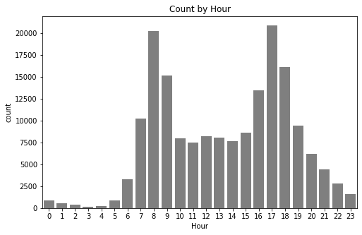

```python
# plot frequency by hours of the day

'''
Histogram method
# plot distribution of trips per hour
# added +2 so hour 23 be a separete bin from hour 22 /instead of +1
# bin for each hour of day
plt.figure(figsize = [8,5])

bins = np.arange(df['start_time'].dt.hour.min(), df['start_time'].dt.hour.max() + 2, 1)
# grid is added by default
df['start_time'].dt.hour.hist(bins = bins , grid = False, color= sb.color_palette()[7])

# add more detailed scale for hours +2 increment
plt.xticks(range(0, 24, 2))
plt.xlabel("Hour")
plt.title("Trips by Hour");'''

plt.figure(figsize = [8,5])

# or sb.barplot(x = df['start_time'].dt.hour.value_counts().index, y= df['start_time'].dt.hour.value_counts(), color = sb.color_palette()[7])
sb.countplot(x = df['hour'], color= sb.color_palette()[7])

plt.title("Count by Hour")
plt.xlabel("Hour");
```

Trips are most frequent in the 3-hour ranges from 7 AM up to 9 AM, and from 4 PM up to 7PM (rush hours periods). Peak hours are 8 AM and 5 PM. Least use from midnight till 6 AM where trips start to show.

Looking at main feature of interest **Duration**

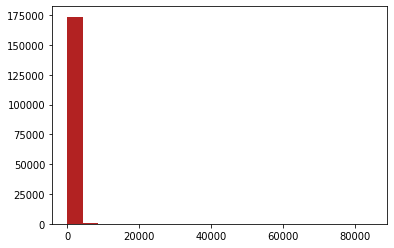

```python
# plot duration distribution
plt.hist(data=df, x= 'duration_sec', bins = 20, color= 'firebrick');
```

```python
np.log10(df['duration_sec'].describe())
```

```
count    5.242770
mean     2.847579
std      3.215495
min      1.785330
25%      2.509203
50%      2.707570
75%      2.897077
max      4.927103
Name: duration_sec, dtype: float64
```

duration distribution would work on a log scale

```python
# set proper x-axis limit cutting info
df[df['duration_sec'] > 5000].shape[0]
```

```
884
```

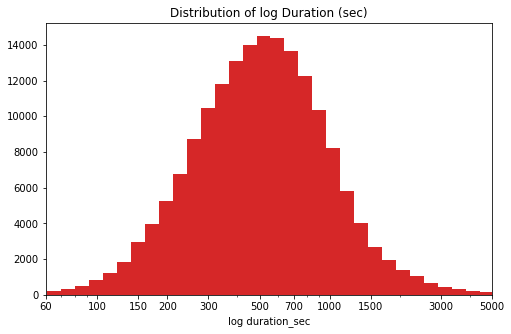

```python
# plot distribution_sec on a log scale
plt.figure(figsize=[8,5])

bins = 10 ** np.arange(1.785330, 4.927103 + 0.06, 0.06)
plt.hist(data=df, x='duration_sec', bins=bins, color= sb.color_palette()[3]);

# log scale of duration_sec
plt.xscale('log')

# limit removes outliers that affect interpretation
plt.xlim(60, 5000)

# to ease view of log scale
ticks = [60, 100, 150, 200, 300, 500, 700, 1000, 1500, 3000, 5000]
labels = ['{}'.format(v) for v in ticks]

# always specify xticks after xscale
plt.xticks(ticks, labels)
plt.xlabel("log duration_sec")
plt.title("Distribution of log Duration (sec)");
```

Check for duration in minutes

```python
# create duration in minutes column
df['duration_min'] = (df['duration_sec'] / 60)
```

```python
# instead of (df['duration_sec'] / 60).describe() created a column
df['duration_min'].describe()
```

```
count    174892.000000
mean     11.733502
std      27.374324
min      1.016667
25%      5.383333
50%      8.500000
75%      13.150000
max      1409.133333
Name: duration_min, dtype: float64
```

```python
# check for elements to limit x-axis values
df[ df['duration_min'] > 30].shape[0]
```

```
6016
```

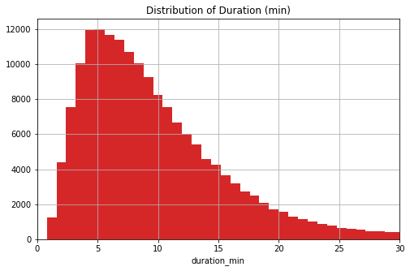

```python
plt.figure(figsize=[8,5])

# take limit up till 30 min as to reduce high outliers effect
bins = np.arange(0, 30 + 0.8, 0.8)
(df['duration_min']).hist(bins = bins, color= sb.color_palette()[3])

plt.xlabel("duration_min")
plt.title("Distribution of Duration (min)")


plt.xlim(0, 30);
```

perform log transform

```python
# compute the logarithm of price to make multivariate plotting easier
def log_trans(x, inverse = False):
    """ quick function for computing log and power operations """
    if not inverse:
        return np.log10(x)
    else:
        return np.power(10, x)

df['log_duration'] = df['duration_min'].apply(log_trans)
```

```python
df.duration_min.describe()
```

```
count    174892.000000
mean     11.733502
std      27.374324
min      1.016667
25%      5.383333
50%      8.500000
75%      13.150000
max      1409.133333
Name: duration_min, dtype: float64
```

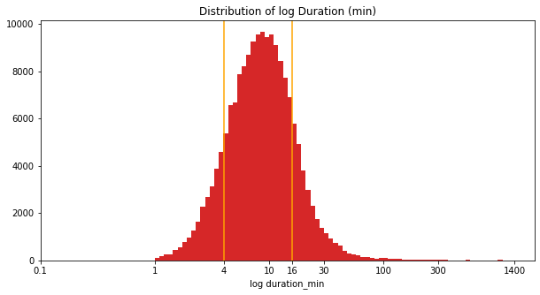

```python
# plot distribution_sec on a log scale

'''
plt.xscale(would be much easier and efficent)
# plot distribution_sec on a log scale
plt.figure(figsize=[10,5])
bin_size = 0.04
bins = 10 ** np.arange(0, 3.148952 + bin_size, bin_size)
plt.hist( x= df['duration_min'] , bins=bins, color= sb.color_palette()[5]);

# log scale of duration_sec
plt.xscale('log')

# limit where most durations lies
#plt.xlim(1, 30)

# to ease view of log scale
ticks =  [ 0.1 , 0.4 , 1 , 4, 10, 16, 30, 100, 300, 1400]
labels = ['{}'.format(v) for v in ticks]

plt.xticks(ticks, labels)
plt.xlabel("log duration_min")
plt.title("Distribution of log Duration (min)")
'''

plt.figure(figsize=[10,5])

bin_size = 0.04
bins = np.arange(0, df['log_duration'].max() + bin_size, bin_size)
plt.hist(data=df, x= 'log_duration' , bins=bins, color= sb.color_palette()[3]);



plt.xlabel("log duration_min")
plt.title("Distribution of log Duration (min)")

ticks = [0.1, 1 , 4, 10, 16, 30, 100, 300, 1400]
tick_locs = log_trans(np.array(ticks))
labels = ['{}'.format(v) for v in ticks]


# Apply x-ticks
plt.xticks(tick_locs, labels);

# highlight boundaries observed from duration_sec log scale
# NOTE: true values on x-axis is np.log10()
plt.axvline(log_trans(4),color = 'orange')
plt.axvline(log_trans(16), color = 'orange');
```

Taking log scale of duration showed details about the distribution of duration.Peak counts of durations are in the range from [400 - 700] secs, around 6.5 - 11.5 minutes after assuring using minutes measure.

Most durations lie in the range [240 - 1000] secs, around 4 - 16 mins. Other than that range is considered an outlier whether high or low. Noticed as well that high outliers are few but have very high values.

Stations column count check

```python
df.start_station_name.nunique()
```

```
329
```

```python
df.start_station_name.value_counts()[:10]
```

```
Market St at 10th St                                         3649
San Francisco Caltrain Station 2  (Townsend St at 4th St)    3407
Berry St at 4th St                                           2952
Montgomery St BART Station (Market St at 2nd St)             2711
Powell St BART Station (Market St at 4th St)                 2620
San Francisco Caltrain (Townsend St at 4th St)               2576
San Francisco Ferry Building (Harry Bridges Plaza)           2540
Howard St at Beale St                                        2216
Steuart St at Market St                                      2191
Powell St BART Station (Market St at 5th St)                 2144
Name: start_station_name, dtype: int64
```

```python
df.end_station_name.value_counts()[:10]
```

```
San Francisco Caltrain Station 2  (Townsend St at 4th St)    4623
Market St at 10th St                                         3709
Montgomery St BART Station (Market St at 2nd St)             3461
San Francisco Ferry Building (Harry Bridges Plaza)           3151
San Francisco Caltrain (Townsend St at 4th St)               2865
Powell St BART Station (Market St at 4th St)                 2854
Berry St at 4th St                                           2782
The Embarcadero at Sansome St                                2341
Steuart St at Market St                                      2264
Powell St BART Station (Market St at 5th St)                 2153
Name: end_station_name, dtype: int64
```

### Discuss the distribution(s) of your variable(s) of interest. Were there any unusual points? Did you need to perform any transformations?

> Duration had a very large scale of values especially high values. Log scale transformation of duration deemed useful and showed details of the distribution. Furhter Investigation of duration in measure of minutes on a log scale as well to confirm insights.  
> Member age column had very high outliers, investigated on limited scale of values cancelling extremly high outliers.

### Of the features you investigated, were there any unusual distributions? Did you perform any operations on the data to tidy, adjust, or change the form of the data? If so, why did you do this?

> Unusual high ages appeared in member_age column when visualizing, removed rows with ages that exceeded the oldest age in the world.  
> Added duration_min column for duration in minutes, as minutes measure is much easier to interpret and limits the range of values (/60). Also, added a column for the log values of duration to assist in log transformation.  
> Added a column for the day of the week (using start time as day of start and end rarely differs), and a column for hour of the day (with an approximation of start hour) to assist in analyzing time frequencies and patterns

## Bivariate Exploration

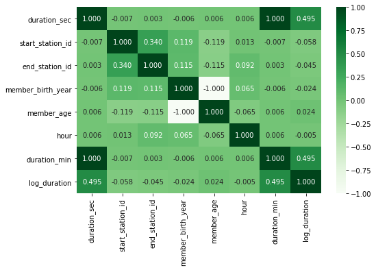

```python
# overall correlation plot
plt.figure(figsize = [8, 5])
sb.heatmap(df.corr(), annot = True, fmt = '.3f',
           cmap = 'Greens', center = 0)
plt.show();
```

Searching Geneder effect on User type

```python
df.groupby(['member_gender', 'user_type']).size()
```

```
member_gender  user_type
Female         Customer      4622
               Subscriber    36180
Male           Customer      11489
               Subscriber    118954
Other          Customer      450
               Subscriber    3197
dtype: int64
```

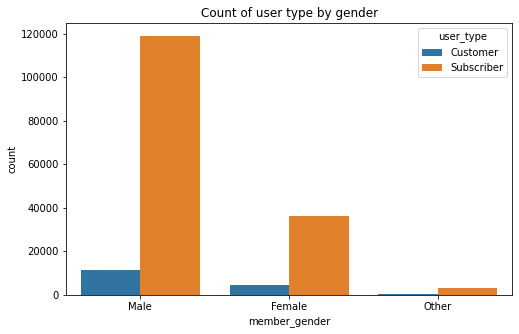

```python
# plot member_gender with user_type
plt.figure(figsize=[8,5])

# order was not set right
sb.countplot(data = df, x = 'member_gender', hue = 'user_type', order = ['Male', 'Female', 'Other'])
plt.title("Count of user type by gender");
```

Clearly, Subscribers are **vast majority Males**, then Females then Other. Ratio of Male Subscribers to total Male is slightly better than that for Female.

Moving to Distribution of age with User types

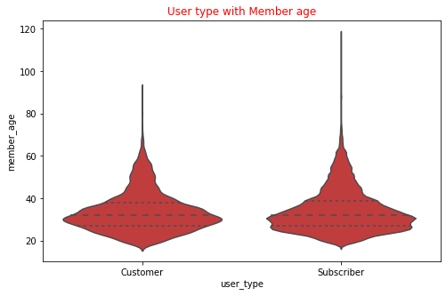

```python
plt.figure(figsize=[8,5])
sb.violinplot(data=df, x='user_type', y='member_age', color=sb.color_palette()[3], inner= 'quartile')

plt.title("User type with Member age", color = 'red');
```

Customer and Subscriber in terms of Member age have similar distributions and quartiles. However, Subscriber is more common within most old ages (very little number of rows)

Searching correlation between member's age and duration in minutes

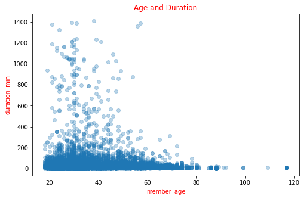

```python
plt.figure(figsize=[8,5])
#plt.subplot(2,1,1)
plt.scatter(data=df, x= 'member_age', y = 'duration_min', alpha = 0.3)

plt.xlabel("member_age", color = 'red')
plt.ylabel("duration_min", color = 'red')
plt.title("Age and Duration", color = 'red')
'''
could do
plt.subplot(2,1,2)

plt.scatter(data=df, x= 'member_age', y = 'duration_min', alpha = 0.2)

plt.xlabel("member_age", color = 'orange')
plt.ylabel("log duration_min", color = 'orange')
plt.title("Age and Duration", color = 'orange')
plt.yscale('log')

ticks =  [ 0.1 , 0.4 , 1 , 4, 10, 16, 30, 100, 300]
labels = ['{}'.format(v) for v in ticks]

plt.yticks(ticks, labels)

plt.ylim(1, 300);''';
```

Looking closely with log transformation of duration

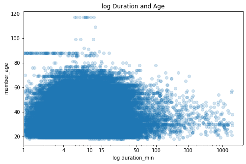

```python
plt.figure(figsize=[8,5])

plt.scatter(data=df, x= 'duration_min', y = 'member_age', alpha = 0.2)

plt.xlabel("log duration_min")
plt.ylabel("member_age")
plt.title("log Duration and Age")
plt.xscale('log')

ticks =  [1, 4, 10, 15, 50, 100, 300, 1000]
labels = ['{}'.format(v) for v in ticks]

plt.xticks(ticks, labels)

plt.xlim(1);
```

There is no indication of corelation between member age and duration. However, very high durations (high outliers) seem to be accompanied with young ages.

Searching the distriution of duration given User type.

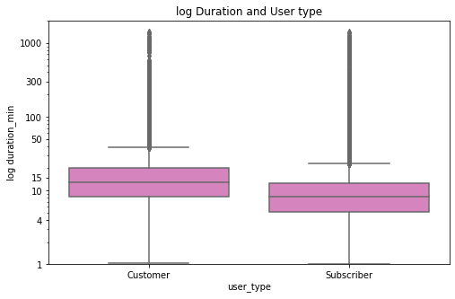

```python
# plot log duration with user type
plt.figure(figsize=[8,5])

sb.boxplot(data=df, x='user_type', y='duration_min', color=sb.color_palette()[6])

plt.yscale('log')

ticks =  [1, 4, 10, 15, 50, 100, 300, 1000]
labels = ['{}'.format(v) for v in ticks]
plt.yticks(ticks, labels)


plt.ylabel("log duration_min")
plt.title("log Duration and User type")

# min duration
plt.ylim(1);
```

Further analysis of user types in range of most durations

durations less than 40 mins, around 3000 rows were canceled (won't affect results)

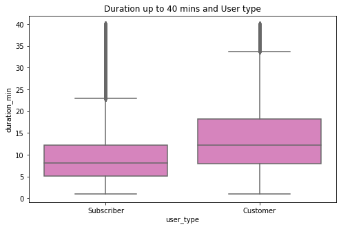

```python
plt.figure(figsize=[8,5])

dur_sub40 = df[df.duration_min <= 40]

sb.boxplot(data=dur_sub40, x='user_type', y='duration_min', color=sb.color_palette()[6])

plt.title("Duration up to 40 mins and User type");
```

Customers tend to have longer durations than Subscribers, which is illustrated clearly in the second plot of main duration range (<= 40 mins). On average a **Subscriber** takes approx **8 mins.** trip duratiton, while a **Customer** takes approx **12 and a half mins.** Seems like Customer uses bikeshare especially for long trips while Subscriber for day-to-day trips.

Day of the month and day of the week by types of users

```python
users_by_day = df.groupby(df.start_time.dt.day)['user_type'].value_counts()
users_by_day
```

```
start_time  user_type
1           Subscriber    5353
            Customer      472
2           Subscriber    2627
            Customer      376
3           Subscriber    2396
            Customer      310
4           Subscriber    4905
            Customer      367
5           Subscriber    7549
            Customer      585
6           Subscriber    8056
            Customer      599
7           Subscriber    8118
            Customer      679
8           Subscriber    5594
            Customer      499
9           Subscriber    2279
            Customer      270
10          Subscriber    3189
            Customer      507
11          Subscriber    7707
            Customer      606
12          Subscriber    7538
            Customer      613
13          Subscriber    2913
            Customer      162
14          Subscriber    5839
            Customer      506
15          Subscriber    6295
            Customer      677
16          Subscriber    3158
            Customer      575
17          Subscriber    3089
            Customer      788
18          Subscriber    4457
            Customer      838
19          Subscriber    8333
            Customer      759
20          Subscriber    8410
            Customer      832
21          Subscriber    8294
            Customer      825
22          Subscriber    7868
            Customer      891
23          Subscriber    4176
            Customer      950
24          Subscriber    3531
            Customer      694
25          Subscriber    6255
            Customer      497
26          Subscriber    4885
            Customer      309
27          Subscriber    6928
            Customer      517
28          Subscriber    8589
            Customer      858
Name: user_type, dtype: int64
```

```python
# divide users type by day

# xs used for multi-index supplied with key -  level 0 is index 0 column
subscriber_by_day = users_by_day.xs('Subscriber', level=1, drop_level=False)
# customer count by day
customer_by_day = users_by_day.xs('Customer', level=1, drop_level=False)


# creates dfs for subscriber and customer
subscriber_by_day = subscriber_by_day.reset_index(name= 'count')
customer_by_day = customer_by_day.reset_index(name= 'count')

subscriber_by_day.columns = ['day_number', 'user_type', 'count']
customer_by_day.columns = ['day_number', 'user_type', 'count']

subscriber_by_day.head()
```

|  | day_number | user_type | count |
| --- | --- | --- | --- |
| 0 | 1 | Subscriber | 5353 |
| 1 | 2 | Subscriber | 2627 |
| 2 | 3 | Subscriber | 2396 |
| 3 | 4 | Subscriber | 4905 |
| 4 | 5 | Subscriber | 7549 |

```python
# count of each user type by weekday
users_weekday = df.groupby(df.weekday)['user_type'].value_counts()

# xs used for multi-index supplied with key from index to keep -  level 0 is index 0 column
subscriber_weekday = users_weekday.xs('Subscriber', level=1, drop_level=False)
# customer count by weekday
customer_weekday = users_weekday.xs('Customer', level=1, drop_level=False)


# creates dfs for subscriber and customer
subscriber_weekday = subscriber_weekday.reset_index(name= 'count')
customer_weekday = customer_weekday.reset_index(name= 'count')

# rename columns to avoid confusion
subscriber_weekday.columns = ['weekday', 'user_type', 'count']
customer_weekday.columns = ['weekday', 'user_type', 'count']

# set order of weekdays as index (could use categorical)
'''
if type is not categorical could pass order using .loc[]
subscriber_weekday = subscriber_weekday.set_index('weekday').loc[weekend_order]
customer_weekday = customer_weekday.set_index('weekday').loc[weekend_order]'''

subscriber_weekday = subscriber_weekday.set_index('weekday')
customer_weekday = customer_weekday.set_index('weekday')
subscriber_weekday.head()
```

| weekday | user_type | count |
| --- | --- | --- |
| Monday | Subscriber | 23324 |
| Tuesday | Subscriber | 28305 |
| Wednesday | Subscriber | 26307 |
| Thursday | Subscriber | 30840 |
| Friday | Subscriber | 25110 |

```python
weekend_order
```

```
['Monday', 'Tuesday', 'Wednesday', 'Thursday', 'Friday', 'Saturday', 'Sunday']
```

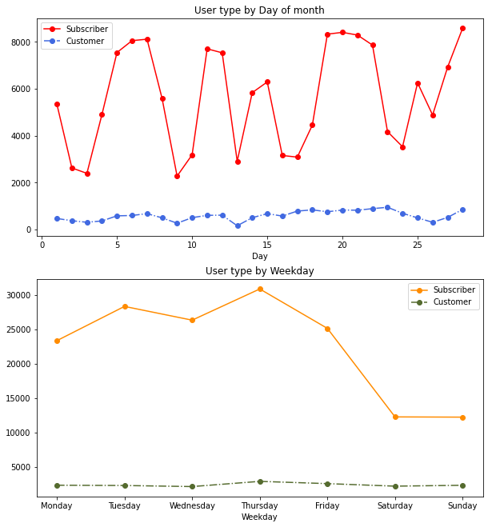

```python
plt.figure(figsize=[10,11])

# plot for user type by day of month
plt.subplot(2,1,1)


# sb.pointplot would difficult adding labels
# Note: marker = , linestyle= instead of style = '-ro'
plt.plot(subscriber_by_day['day_number'], subscriber_by_day['count'], color = 'red', label = 'Subscriber', marker='o', linestyle='solid')
plt.plot(customer_by_day['day_number'], customer_by_day['count'], color = 'royalblue', label = 'Customer', marker='o', linestyle='dashdot')

# could add index start = 1
plt.title("User type by Day of month")
plt.xlabel("Day")
plt.legend();
# plot for user type by weekday
plt.subplot(2,1,2)
# plot has no order attribute so set weekday index
plt.plot(subscriber_weekday.index, subscriber_weekday['count'], color = 'darkorange', label = 'Subscriber', marker='o', linestyle='solid')
plt.plot(customer_weekday.index, customer_weekday['count'], color = 'darkolivegreen', label = 'Customer', marker='o', linestyle='dashdot')

plt.title("User type by Weekday")
plt.xlabel("Weekday")
plt.legend();
```

Plot also highlights the huge diffrence between no. of Subscribers and no. of Customers.

Looking closely at relation between Duration and Hour of the day

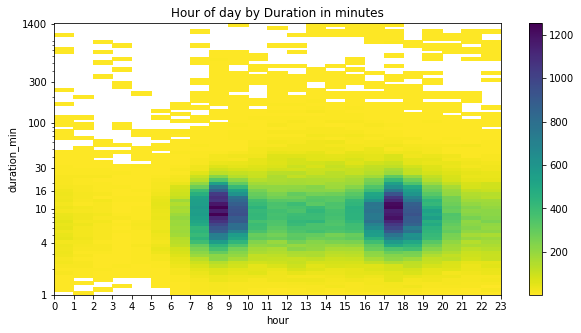

```python
plt.figure(figsize = [10,5])
bins_x = np.arange(0, df['hour'].max() + 1, 1)

bin_size = 0.04
bins_y = 10 ** np.arange(0, df['log_duration'].max() + bin_size, bin_size)

plt.hist2d(data = df, x = 'hour', y = 'duration_min', cmin=0.5, cmap='viridis_r', bins = [bins_x, bins_y])
plt.colorbar()
plt.yscale('log');

# Notice the areas of high frequency in the middle of the negative trend in the plot.
ticks = [1 , 4, 10, 16, 30, 100, 300, 1400]
labels = ['{}'.format(v) for v in ticks]

plt.yticks(ticks, labels)
#plt.xlim(1,40);
plt.xticks(np.arange(0,24,1))
plt.xlabel('hour')
plt.ylabel('duration_min')
plt.title("Hour of day by Duration in minutes");
```

The region from hour 7 AM to hour 10 AM, and from hour 4PM to 7PM is the most dense where majority of durations lie in the range of 4 to 16 mins with peak at approx 10 mins. High outliers seem to be more common during night hours of the day.

Searching start and end stations for relevant effect on duration. Plot of first 10 start and end stations by frequency with mean duration in mins

```python
# take first 10 occurence of start and end stations
first10_startst = df[df.start_station_name.isin(df.start_station_name.value_counts()[:10].index)].groupby('start_station_name')['duration_min'].mean()
end10_startst = df[df.end_station_name.isin(df.end_station_name.value_counts()[:10].index)].groupby('end_station_name')['duration_min'].mean()
```

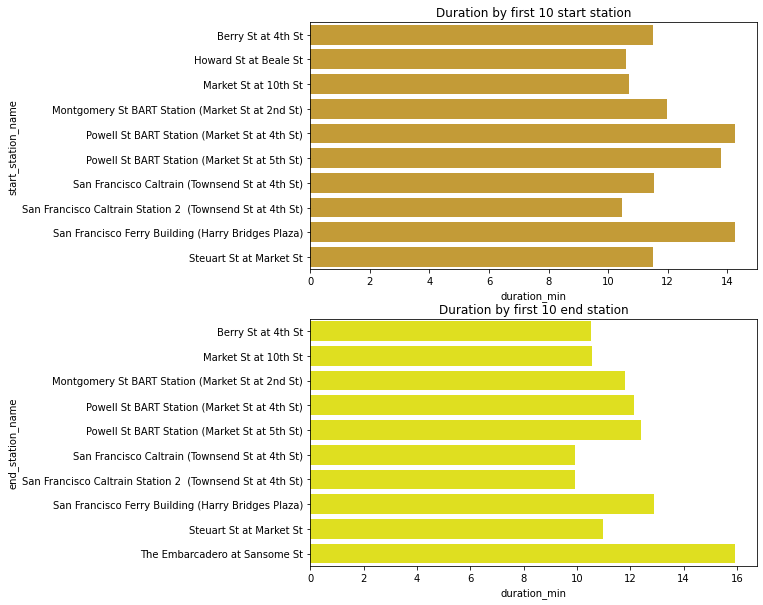

```python
# plot average duration with 10 stations
plt.figure(figsize=[8,10])
plt.subplot(2,1,1)
sb.barplot(x=first10_startst, y= first10_startst.index, color = 'goldenrod')
plt.title("Duration by first 10 start station")

plt.subplot(2,1,2)
sb.barplot(x=end10_startst, y= end10_startst.index, color = 'yellow')
plt.title("Duration by first 10 end station");
```

There doesn't seem to be a strong effect of start or end stations on duration. Would not take stations for further search of main factors.

### Talk about some of the relationships you observed in this part of the investigation. How did the feature(s) of interest vary with other features in the dataset?

> Investigated correlation between member's age and duration but no strong correlation could be observed. Subscriber is majority Male and is more common than Customer among older ages. Distribution of User type with Duration tells that Customer tends to have longer trips than Subscriber. Stations don't seem to have a strong effect on duration and wouldn't be a major asset to further investigate.

## Multivariate Exploration

Looking at distribution of age taking into account Gender and User type

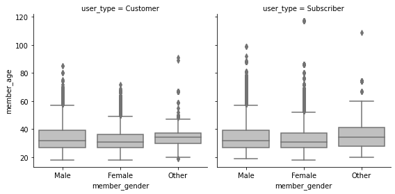

```python
g = sb.FacetGrid(data = df, col = 'user_type', height = 4)
g.map(sb.boxplot, 'member_gender', 'member_age', color = 'silver', order= ['Male', 'Female', 'Other']);
```

Member age don't noticeably differ with respect to Gender and User type, noticed that Male and Female of older age are likely to be Subscribers than Customers. Other has on average highest age with a slight advantage.

Filtering User types to get distribution of age for Bike share for all (Subscribers-based)

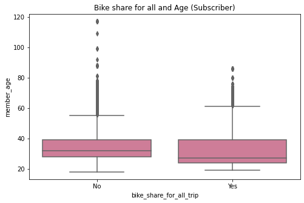

```python
# select only subscribers to show bike share for all
bike_forall = df[df.user_type == 'Subscriber']
plt.figure(figsize = [8,5])
#plot bike share age
sb.boxplot(data = bike_forall, x = 'bike_share_for_all_trip', y = 'member_age', color = 'palevioletred')

plt.title("Bike share for all and Age (Subscriber)");
```

No noticable diffrences in distribution. However, members in bike share for all have on average slightly younger ages than members who are not.

Looking at user types with respect to gender and day of the week.

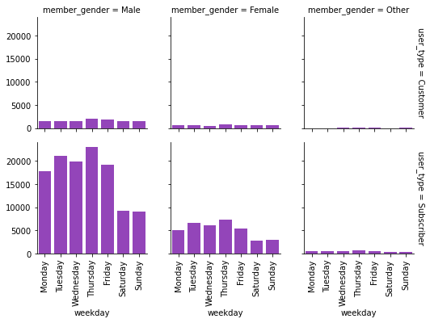

```python
# Plot count by terms of weekday, member_gender and user_type (three categorical vars)

# ignore warning (needs order for weekday categorical ordinal var)
g = sb.FacetGrid(data = df, col = 'member_gender', row = 'user_type', height = 2.5,
                margin_titles = True, col_order = ['Male', 'Female', 'Other'])
g.map(sb.countplot, 'weekday', color ='darkorchid')

# sets the ticks for all columns (xticks set only the first)
g.set_xticklabels(rotation = 90);
```

Patterns of the same User type seems similar across Genders. Subscribers across Genders have a peak on Thursday and a second on Tuesday.

Plots highlight the huge diffrence in counts between Genders with a far advantage for Male.

Searching distributions of duration with respect to day of the week and User type

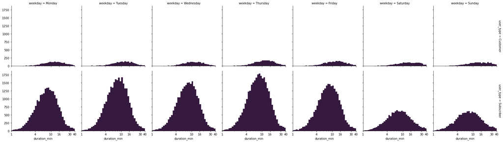

```python
bin_size = 0.04
bins = 10 ** np.arange(0, df['log_duration'].max() + bin_size, bin_size)

g = sb.FacetGrid(data = df, col = 'weekday', row = 'user_type', height = 3.5,
                margin_titles = True)
g.map(plt.hist, 'duration_min', bins=bins, color=sb.color_palette("rocket")[0])
plt.xscale('log')

ticks =  [ 1 , 4, 10, 16, 30, 40]
labels = ['{}'.format(v) for v in ticks]

plt.xticks(ticks, labels)
plt.xlim(1,40);
```

Histogram plots further illustrate that Customer tend to have longer trips than Subscriber and the trips drop on weekends. Noticeably, duration trips for subscriber on Monday and Friday seem to be shorter than other weekdays.

Looking at average duration for gender and user type

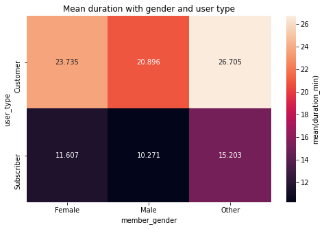

```python
#plot mean duration_min given member_gender and user_type
plt.figure(figsize=[8,5])
means = df.groupby(['user_type', 'member_gender']).mean()['duration_min']
means = means.reset_index(name = 'duration_min_avg')
means = means.pivot(index = 'user_type', columns = 'member_gender',values = 'duration_min_avg')
sb.heatmap(means, annot = True, fmt = '.3f',
           cbar_kws = {'label' : 'mean(duration_min)'})
plt.title("Mean duration with gender and user type");
```

Interestingly, male has the least duration time both subscriber and customers. Female exceeds male in the duration of trips while Other has highest duration time on average. Noticeably, there is a huge gap between durations between Subscriber and Customer for all gender, with Customer exceeding with approx 10 mins on average.

Relation between hour of the day and duration given user type

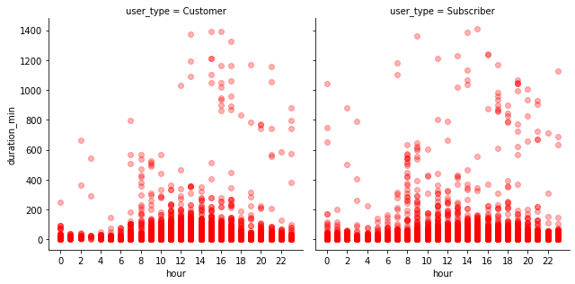

```python
g = sb.FacetGrid(data = df,  col = 'user_type', height = 4.5,
                margin_titles = True)
g.map(plt.scatter,'hour', 'duration_min', color='red', alpha=0.3)

plt.xticks(np.arange(0,24,2));
```

Scatter plots between hour of the day and duration are similar and don't illustrate much details for different User types

```python
#### store clean df for slide
df.to_csv('master.csv',  index=False)
```

### Talk about some of the relationships you observed in this part of the investigation. Were there features that strengthened each other in terms of looking at your feature(s) of interest?

> When looking at distribution of age for bikeshare for all filtering only subscribers, Subscribers who are in bikeshare for all tend to be younger than those who are not. Looking at duration distribution, subscribers tend to have slightly shorter trip durations on Monday and Friday than other weekdays.

### Were there any interesting or surprising interactions between features?

> Interestingly, Male tend to have shortest durations on average whether subscriber or customer, with Ohter having longest duration trips for both user types and Female second. Subscribers across gender have peak counts on Tuesday and Thursday. Noticaebly that subscribers tend to have shorter trips on start and end of the weekdays.